# Prática Aula 3 - Estatística descritiva - 2020-2

Clarissa F. D. Carneiro

28/12/2020

O objetivo desta prática é o de explorar os recursos do R para trabalhar com gráficos e diversas medidas sumarizadoras.

1. Carregue o banco de dados “ToothGrowth”, que corresponde a um experimento que mediu o crescimento de osteoblastos em porquinhos-da-índia após administração de vitamina C na forma de ácido ascórbico ou suco de laranja em três doses. Como este é um banco de dados que já vem com os pacotes base de R, basta digitar o comando abaixo no console ou clicar no triângulo verde abaixo:

```r
data("ToothGrowth")
```

2. Abra a planilha clicando no símbolo de tabela ao lado do item ToothGrowth que apareceu no ‘Environment’ (no quadrante superior direito).
3. A coluna ‘len’ contém os valores de crescimento dos osteoblastos. A coluna ‘supp’ indica se o tratamento foi com ácido ascórbico (VC) ou com suco de laranja (OJ). A coluna ‘dose’ indica a dose em miligramas por dia.
4. Vamos precisar de dois pacotes adicionais para as próximas atividades: dplyr e ggplot2. Para instalá-los você pode ir na aba “Packages” (no quandrante inferior direito) e clicar em ‘Install’ (canto superior esquerdo deste quadrante). Digite o nome do pacote e clique em ‘Install’. Uma outra opção é digitar: install.packages(x) Onde x deve ser o nome do pacote desejado.
5. A instalação será necessária apenas no primeiro uso, mas todas as vezes que abrir o RStudio e quiser usar estes pacotes será necessário carregá-los. Para isso, você pode encontrar o pacote na lista e clicar nele ou você pode digitar: library(x) Onde x deve ser o nome do pacote desejado.

```r
library(dplyr)
```

```r
library(ggplot2)
```

6. Após carregar estes dois pacotes, vamos calcular as medidas de tendência central e de dispersão. Para obter as medidas de cada tratamento e em cada dosagem, é preciso agrupar essas observações. Para isso, vamos usar a função group_by(x,…). Dentro dela, iremos colocar as colunas pelas quais queremos agrupar nossos valores, ou seja, ‘supp’ e ‘dose’. A sintaxe usada pelo dplyr envolve o uso de ‘pipes’, representados por %>%. Isso irá indicar a ordem que queremos processar nosso banco de dados. Com isso, por enquanto nós temos:

```r
 ToothGrowth %>% group_by(supp, dose)
```

```
## # A tibble: 60 x 3
## # Groups:   supp, dose [6]
##      len supp   dose
##    <dbl> <fct> <dbl>
##  1   4.2 VC      0.5
##  2  11.5 VC      0.5
##  3   7.3 VC      0.5
##  4   5.8 VC      0.5
##  5   6.4 VC      0.5
##  6  10   VC      0.5
##  7  11.2 VC      0.5
##  8  11.2 VC      0.5
##  9   5.2 VC      0.5
## 10   7   VC      0.5
## # … with 50 more rows
```

```r
# como não queremos que ele rode o código ainda, colocamos o # no início da linha.
```

7. Para incluir os cálculos que estamos interessados, vamos usar um outro pipe e a função summarise(). Dentro desta função nós podemos pedir, por exemplo, a média dos crescimentos:

```r
ToothGrowth %>% group_by(supp, dose) %>% summarise(mean(len))
```

```
## # A tibble: 6 x 3
## # Groups:   supp [2]
##   supp   dose `mean(len)`
##   <fct> <dbl>       <dbl>
## 1 OJ      0.5       13.2
## 2 OJ      1         22.7
## 3 OJ      2         26.1
## 4 VC      0.5        7.98
## 5 VC      1         16.8
## 6 VC      2         26.1
```

8. Para obter o desvio padrão, substituímos mean por sd.

```r
ToothGrowth %>% group_by(supp, dose) %>% summarise(sd(len))
```

```
## # A tibble: 6 x 3
## # Groups:   supp [2]
##   supp   dose `sd(len)`
##   <fct> <dbl>     <dbl>
## 1 OJ      0.5      4.46
## 2 OJ      1        3.91
## 3 OJ      2        2.66
## 4 VC      0.5      2.75
## 5 VC      1        2.52
## 6 VC      2        4.80
```

9. Podemos ainda guardar estes valores, vamos precisar deles daqui a pouco:

```r
media = ToothGrowth %>% group_by(supp, dose) %>% summarise(media = mean(len))
desvio = ToothGrowth %>% group_by(supp, dose) %>% summarise(sd = sd(len))
ambos = full_join(media, desvio)
```

10. Para visualizar esse conjunto de dados, o pacote ggplot2 usa uma sintaxe de camadas. Primeiro vem a função base ggplot(), onde definimos qual o banco de dados que queremos usar e que variáveis devem corresponder a que elementos no gráfico (em cada eixo, ou ainda cores, tamanhos, transparência…). Depois, vem a camada geom, que irá variar de acordo com o tipo de gráfico. Para um scatter plot, nós temos:

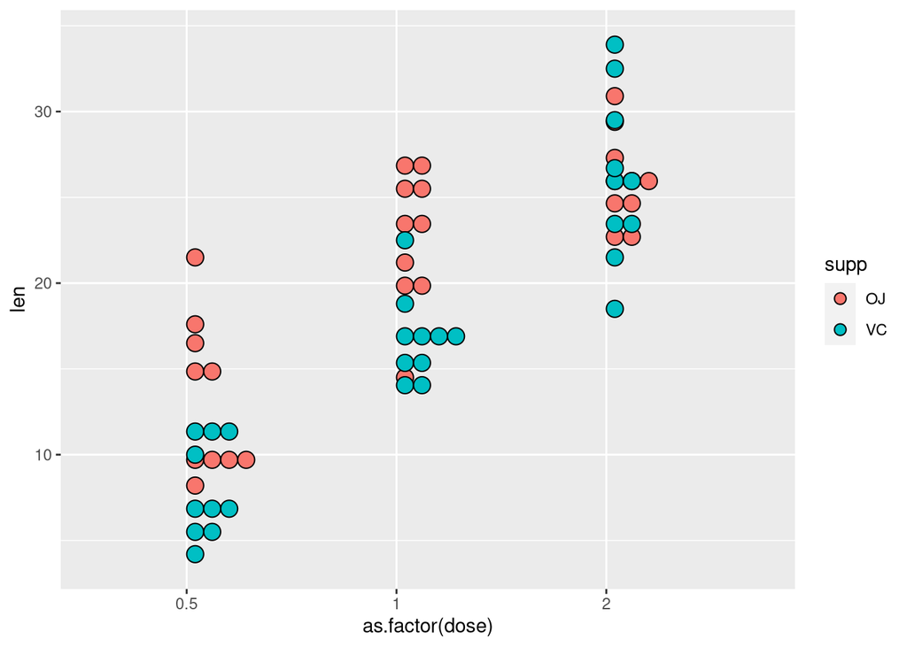

```r
ggplot(ToothGrowth, aes(x = as.factor(dose), y = len, fill = supp)) +
  geom_dotplot(binaxis = "y")
```

Observe que pedimos para que a dose seja considerada uma variável discreta usando a função as.factor(). Para que a cor corresponda ao tratamento, usamos o parâmetro fill e o R escolheu cores automaticamente e criou uma legenda. Para alterar as cores manualmente, podemos usar uma terceira camada adicionando + scale_fill_manual(values = c(“…”)). Os parâmetros a serem usados são as cores em código HEX (uma forma fácil de encontrar os códigos é com este site https://htmlcolorcodes.com/). Então temos agora:

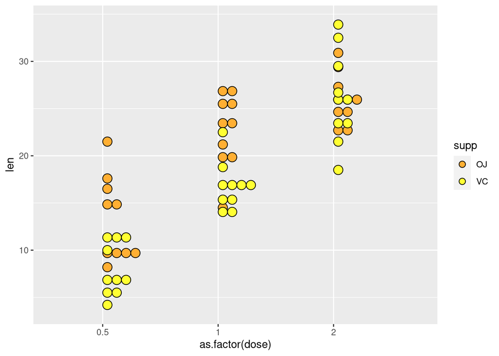

```r
ggplot(ToothGrowth, aes(x = as.factor(dose), y = len, fill = supp)) +
  geom_dotplot(binaxis = "y") +
  scale_fill_manual(values = c("#ffaf33","#ffff33"))
```

11. Observe o eixo y gerado automaticamente. Se ele não começa do zero, nós podemos definir isso manualmente também adicionando mais uma camada ao nosso código:

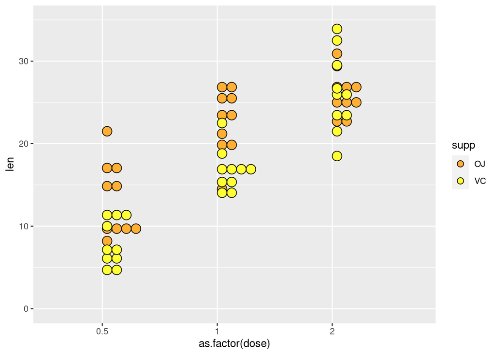

```r
ggplot(ToothGrowth, aes(x = as.factor(dose), y = len, fill = supp)) +
  geom_dotplot(binaxis = "y") +
  scale_fill_manual(values = c("#ffaf33","#ffff33")) +
  scale_y_continuous(limits = c(0,35))
```

Usando ainda esta mesma camada, podemos alterar o título do eixo para algo mais elucidativo usando o parâmetro ‘name’.

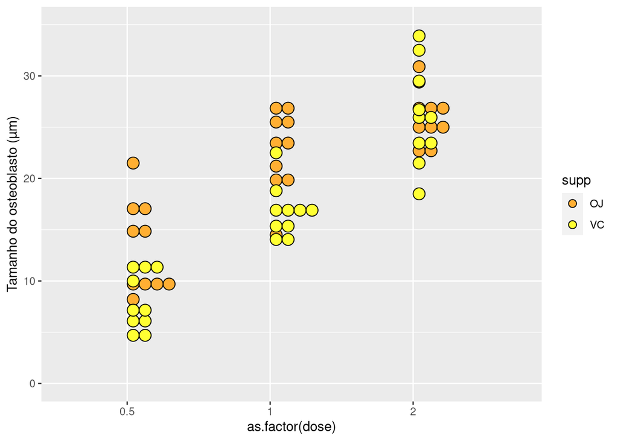

```r
ggplot(ToothGrowth, aes(x = as.factor(dose), y = len, fill = supp)) +
  geom_dotplot(binaxis = "y") +
  scale_fill_manual(values = c("#ffaf33","#ffff33")) +
  scale_y_continuous(limits = c(0,35), name = "Tamanho do osteoblasto (µm)")
```

Mais alguns ajustes estéticos para tornar o gráfico mais legível:

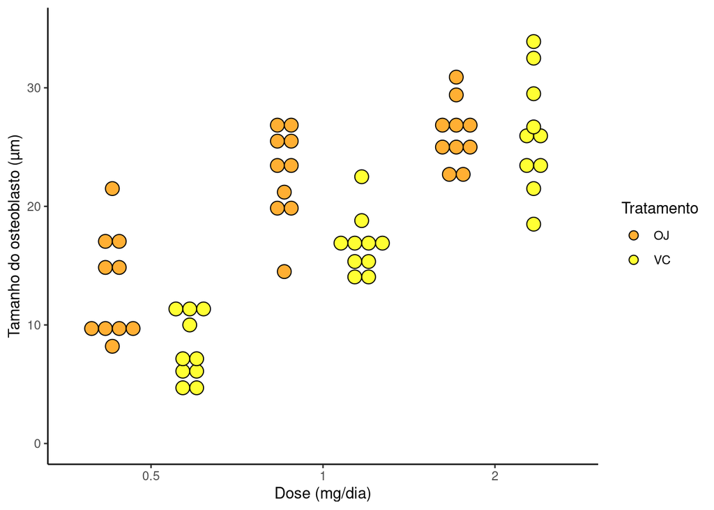

```r
ggplot(ToothGrowth, aes(x = as.factor(dose), y = len, fill = supp)) +
  geom_dotplot(binaxis = "y", position = "dodge", stackdir = "center") +
  scale_fill_manual(values = c("#ffaf33","#ffff33")) +
  scale_y_continuous(limits = c(0,35), name = "Tamanho do osteoblasto (µm)") +
  labs(x = "Dose (mg/dia)", fill = "Tratamento") +
  theme_classic()
```

12. Vamos agora fazer um gráfico de barras com a média e desvio padrão calculados anteriormente. Para isso, copiamos o código anterior com algumas alterações: mudamos o dataset para “ambos” (com isso o nome da variável y também muda) e mudamos a função geom para geom_bar (com isso, os parâmetros também mudam).

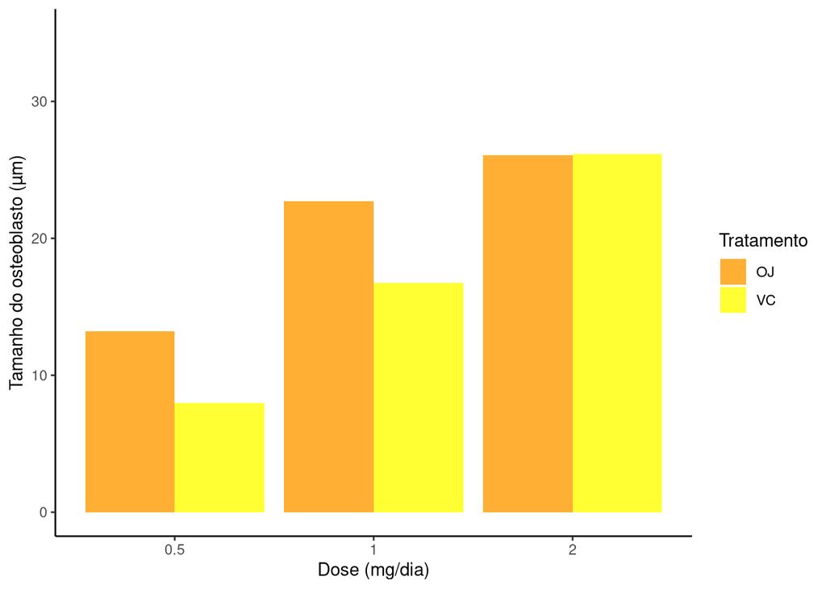

```r
ggplot(ambos, aes(x = as.factor(dose), y = media, fill = supp)) +
  geom_bar(stat = "identity", position = "dodge") +
  scale_fill_manual(values = c("#ffaf33","#ffff33")) +
  scale_y_continuous(limits = c(0,35), name = "Tamanho do osteoblasto (µm)") +
  labs(x = "Dose (mg/dia)", fill = "Tratamento") +
  theme_classic()
```

Para adicionar o desvio padrão, precisamos adicionar outra camada:

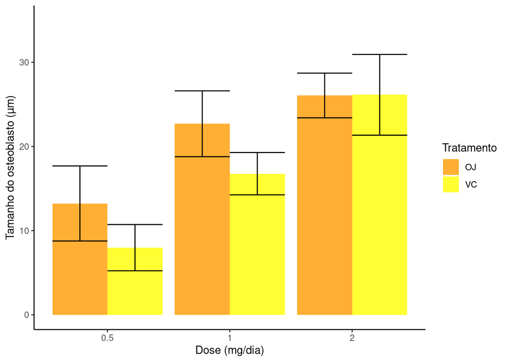

```r
ggplot(ambos, aes(x = as.factor(dose), y = media, fill = supp)) +
  geom_bar(stat = "identity", position = "dodge") +
  scale_fill_manual(values = c("#ffaf33","#ffff33")) +
  scale_y_continuous(limits = c(0,35), name = "Tamanho do osteoblasto (µm)") +
  labs(x = "Dose (mg/dia)", fill = "Tratamento") +
  theme_classic() +
  geom_errorbar(aes(ymin=media-sd, ymax=media+sd), position = "dodge")
```

13. Também podemos combinar os gráficos criados, por exemplo adicionando o geom_dotplot ao gráfico de barras. Como eles usam dados diferentes, algumas pequenas alterações são necessárias dentro desta camada:

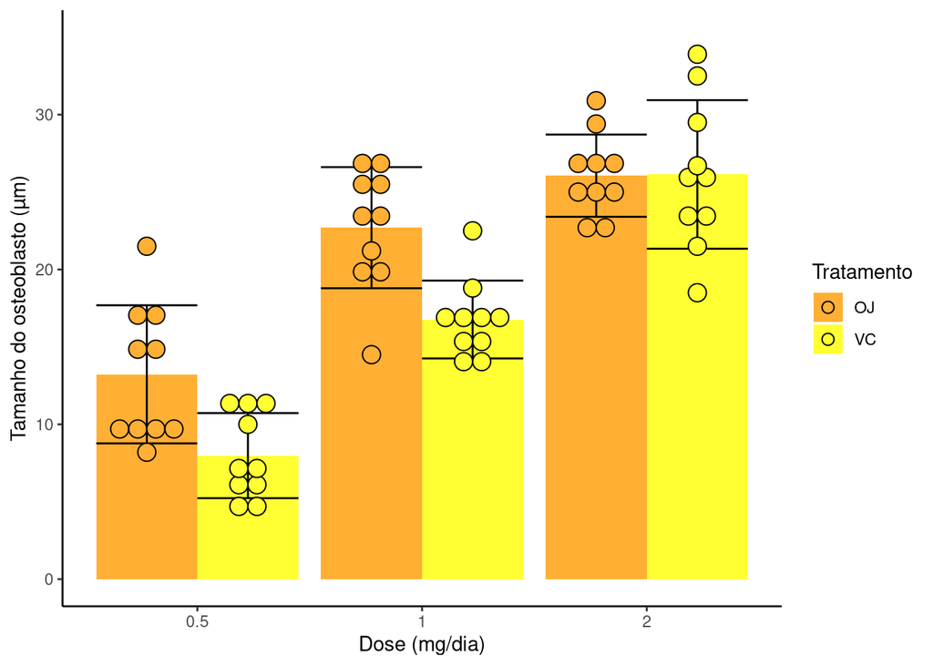

```r
ggplot(ambos, aes(x = as.factor(dose), y = media, fill = supp)) +
  geom_bar(stat = "identity", position = "dodge") +
  scale_fill_manual(values = c("#ffaf33","#ffff33")) +
  scale_y_continuous(limits = c(0,35), name = "Tamanho do osteoblasto (µm)") +
  labs(x = "Dose (mg/dia)", fill = "Tratamento") +
  theme_classic() +
  geom_errorbar(aes(ymin=media-sd, ymax=media+sd), position = "dodge") +
  geom_dotplot(data = ToothGrowth, aes(x = as.factor(dose), y = len, fill = supp), binaxis = "y", position = "dodge", stackdir = "center")
```

14. Mantendo esta estrutura de camadas é possível criar uma variedade enorme de gráficos, dê uma olhada em https://www.r-graph-gallery.com/ para uma lista de possibilidades.
15. Agora experimente fazer um gráfico usando seus próprios dados. Para isso, é preciso que você tenha o arquivo .xlsx ou .csv com a mesma estrutura apresentada acima – ou seja, cada linha deve ser uma observação e cada coluna uma variável. Para importar os dados para o RStudio, você pode usar o botão “Import dataset” (localizado no quadrante superior esquerdo). Observe que usando este botão o programa vai escrever os comandos por você, mas o mesmo código poderia ter sido escrito diretamente em “Console”.